# Prior Analysis

Susannah Tysor

28/04/2020

## Prior choice

In my original phenology model, I use

- a gamma distribution for the prior on the cutpoints
- an exponential distribution distribution for the transition speed/slope $\beta$
  - normal distributions for group effects on the slope

Michael Betancourt thinks that an induced dirichlet prior may be a [good choice](https://betanalpha.github.io/assets/case_studies/ordinal_regression.html) for ordinal logistic models.

Normally, priors are bottom up - you choose a distribution for each prior. This is tricky for the cutpoints in an ordinal logistic model because they’re defined on an abstract latent space so you can’t easily use your domain expertise, but a good prior is incredibly important in these models, because ordered logistic models with covariates are inherently non-identifiable. (Because $beta$s and cutpoints depend on one another.)

Betancourt says that > To avoid the non-identifiability of the interior cut points from propagating to the posterior distribution we need a principled prior model that can exploit domain expertise to consistently regularize all of the internal cut points at the same time. Regularization of the cut points, however, is subtle given their ordering constraint. Moreover domain expertise is awkward to apply on the abstract latent space where the internal cut points are defined.

# Goals

1. Understand the dynamics of the gamma and induced dirichlet priors and 2) compare them

# Simulate data

First let’s simulate some data that’s kind of like mine.

We have three potential states `K` and a latent effect/covariate `x`. Data is most likely to be collected around state 2. `x` is always positive.

Here is what a slow (beta=0.5) and fast (beta=2) transition look like. My data is more like the fast transition - a phenological period with transitions of beta=0.5 would be occuring over a really long time period.

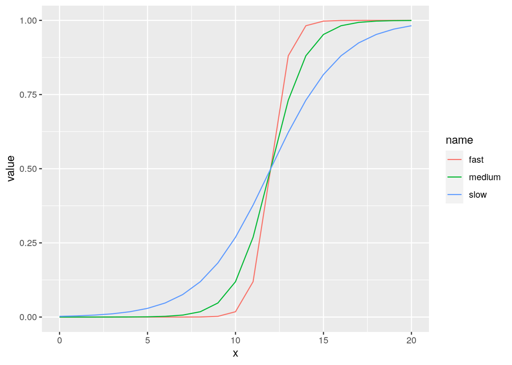

## Simulate datasets

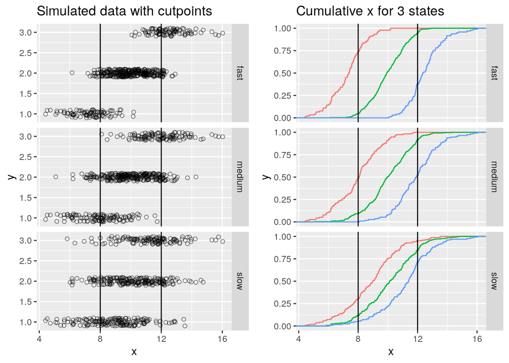

## Recapture parameters: Gamma

Now I want to try to recapture parameters.

I also want to understand how the exponential prior on beta affects the ability to recapture parameters. I’ll try rates of 1,2,3.

### Gamma prior with covariate

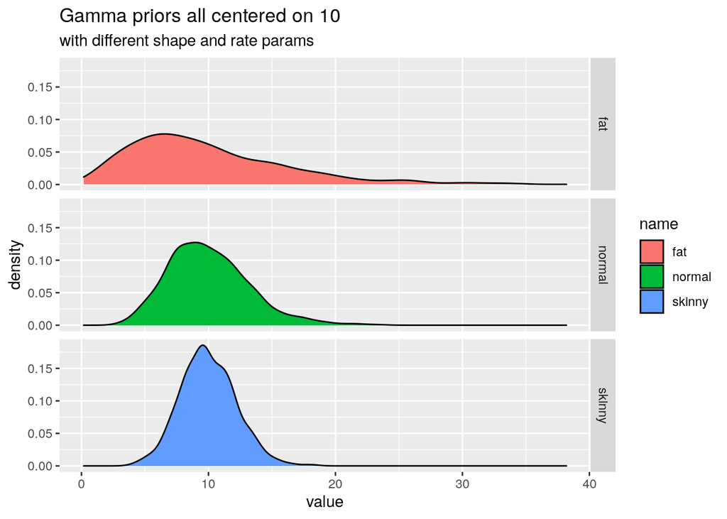

model configurations used to try to recapture params

| gammaid | shape | cut_rate | beta_rate | transition | beta | c.1 | c.2 | h1 | h2 | modelid |
| --- | --- | --- | --- | --- | --- | --- | --- | --- | --- | --- |
| fat | 2.5 | 0.25 | 1 | fast | 2.0 | 16 | 24 | 8 | 12 | 1 |
| normal | 10.0 | 1.00 | 1 | fast | 2.0 | 16 | 24 | 8 | 12 | 2 |
| skinny | 20.0 | 2.00 | 1 | fast | 2.0 | 16 | 24 | 8 | 12 | 3 |
| fat | 2.5 | 0.25 | 2 | fast | 2.0 | 16 | 24 | 8 | 12 | 4 |
| normal | 10.0 | 1.00 | 2 | fast | 2.0 | 16 | 24 | 8 | 12 | 5 |
| skinny | 20.0 | 2.00 | 2 | fast | 2.0 | 16 | 24 | 8 | 12 | 6 |
| fat | 2.5 | 0.25 | 3 | fast | 2.0 | 16 | 24 | 8 | 12 | 7 |
| normal | 10.0 | 1.00 | 3 | fast | 2.0 | 16 | 24 | 8 | 12 | 8 |
| skinny | 20.0 | 2.00 | 3 | fast | 2.0 | 16 | 24 | 8 | 12 | 9 |
| fat | 2.5 | 0.25 | 1 | medium | 1.0 | 8 | 12 | 8 | 12 | 10 |
| normal | 10.0 | 1.00 | 1 | medium | 1.0 | 8 | 12 | 8 | 12 | 11 |
| skinny | 20.0 | 2.00 | 1 | medium | 1.0 | 8 | 12 | 8 | 12 | 12 |
| fat | 2.5 | 0.25 | 2 | medium | 1.0 | 8 | 12 | 8 | 12 | 13 |
| normal | 10.0 | 1.00 | 2 | medium | 1.0 | 8 | 12 | 8 | 12 | 14 |
| skinny | 20.0 | 2.00 | 2 | medium | 1.0 | 8 | 12 | 8 | 12 | 15 |
| fat | 2.5 | 0.25 | 3 | medium | 1.0 | 8 | 12 | 8 | 12 | 16 |
| normal | 10.0 | 1.00 | 3 | medium | 1.0 | 8 | 12 | 8 | 12 | 17 |
| skinny | 20.0 | 2.00 | 3 | medium | 1.0 | 8 | 12 | 8 | 12 | 18 |
| fat | 2.5 | 0.25 | 1 | slow | 0.5 | 4 | 6 | 8 | 12 | 19 |
| normal | 10.0 | 1.00 | 1 | slow | 0.5 | 4 | 6 | 8 | 12 | 20 |
| skinny | 20.0 | 2.00 | 1 | slow | 0.5 | 4 | 6 | 8 | 12 | 21 |
| fat | 2.5 | 0.25 | 2 | slow | 0.5 | 4 | 6 | 8 | 12 | 22 |
| normal | 10.0 | 1.00 | 2 | slow | 0.5 | 4 | 6 | 8 | 12 | 23 |
| skinny | 20.0 | 2.00 | 2 | slow | 0.5 | 4 | 6 | 8 | 12 | 24 |
| fat | 2.5 | 0.25 | 3 | slow | 0.5 | 4 | 6 | 8 | 12 | 25 |
| normal | 10.0 | 1.00 | 3 | slow | 0.5 | 4 | 6 | 8 | 12 | 26 |
| skinny | 20.0 | 2.00 | 3 | slow | 0.5 | 4 | 6 | 8 | 12 | 27 |

So there are 3 simulated datasets - 1 for each of three transition speeds. I’m going to try to fit them both with 3 rates for the beta’s exponential prior and 3 shape and rate combinations for the cutpoints’ gamma prior, a total of 27 model runs.

[output not shown]

[output cut: 64 more lines]

[output not shown]

```
## $`1`
```

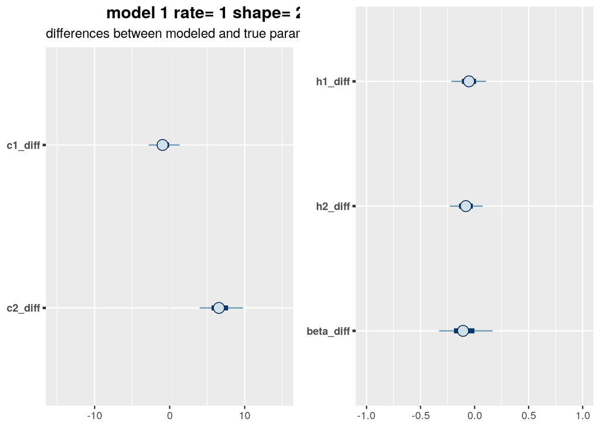

```
##
## $`2`
```

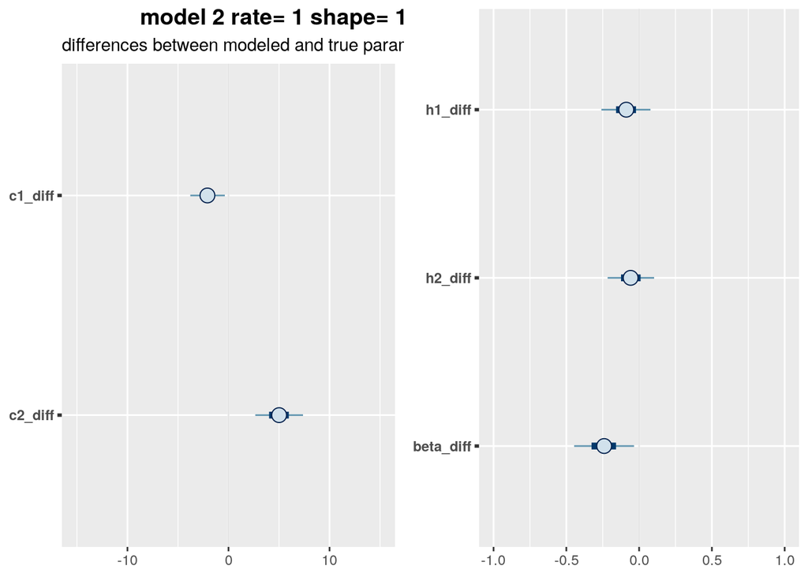

```
##
## $`3`
```

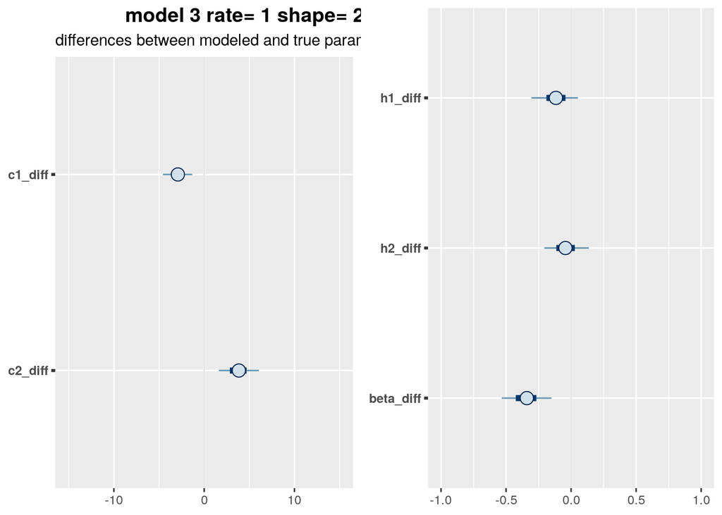

```
##
## $`4`
```

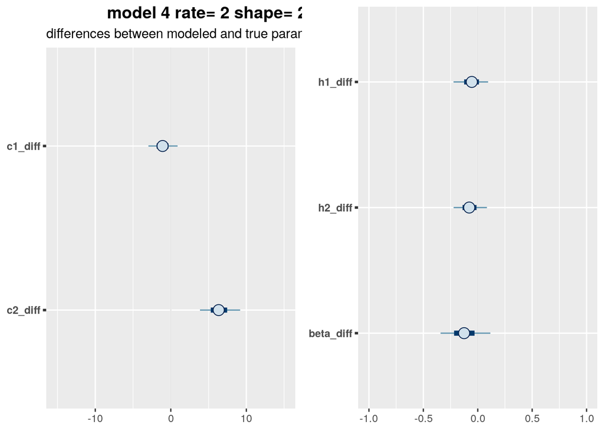

```
##
## $`5`
```

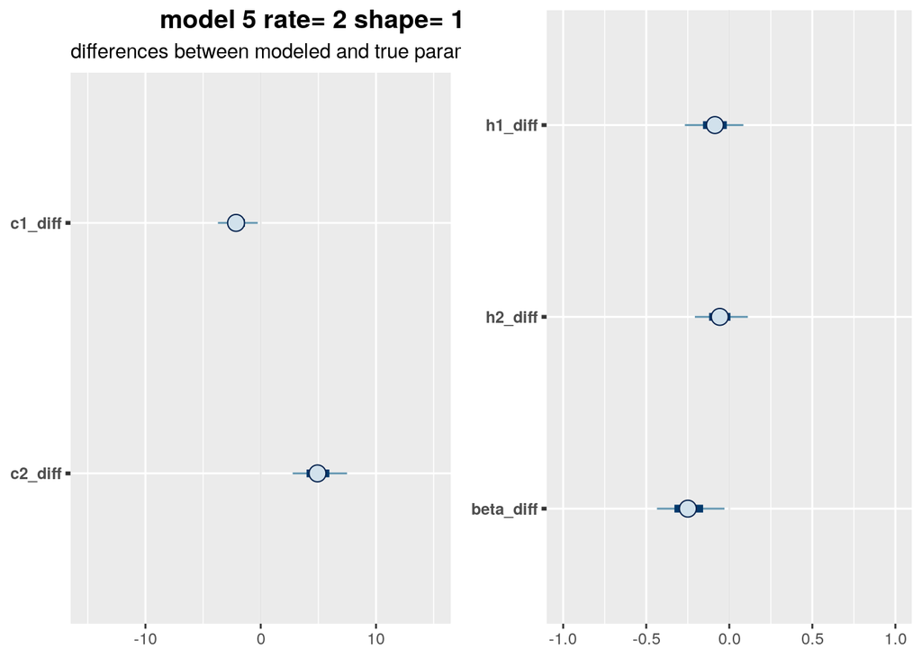

```
##
## $`6`
```

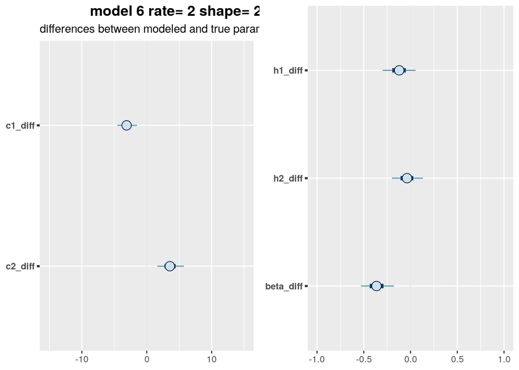

```
##
## $`7`
```

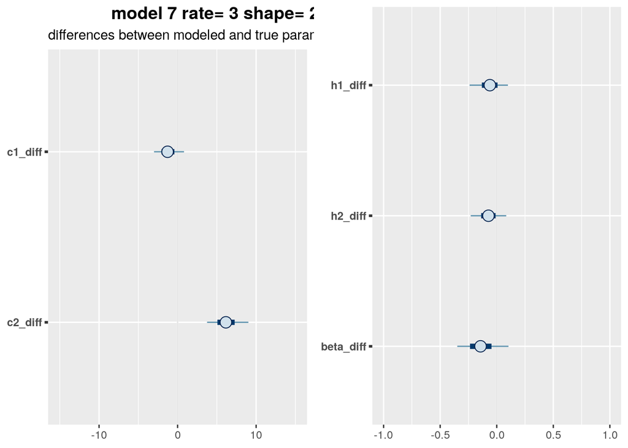

```
##
## $`8`
```

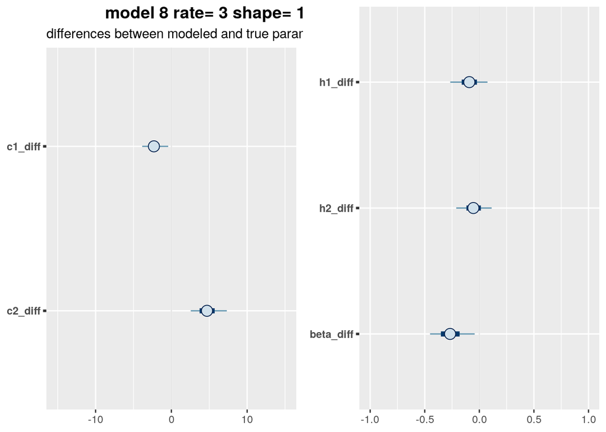

```
##
## $`9`
```

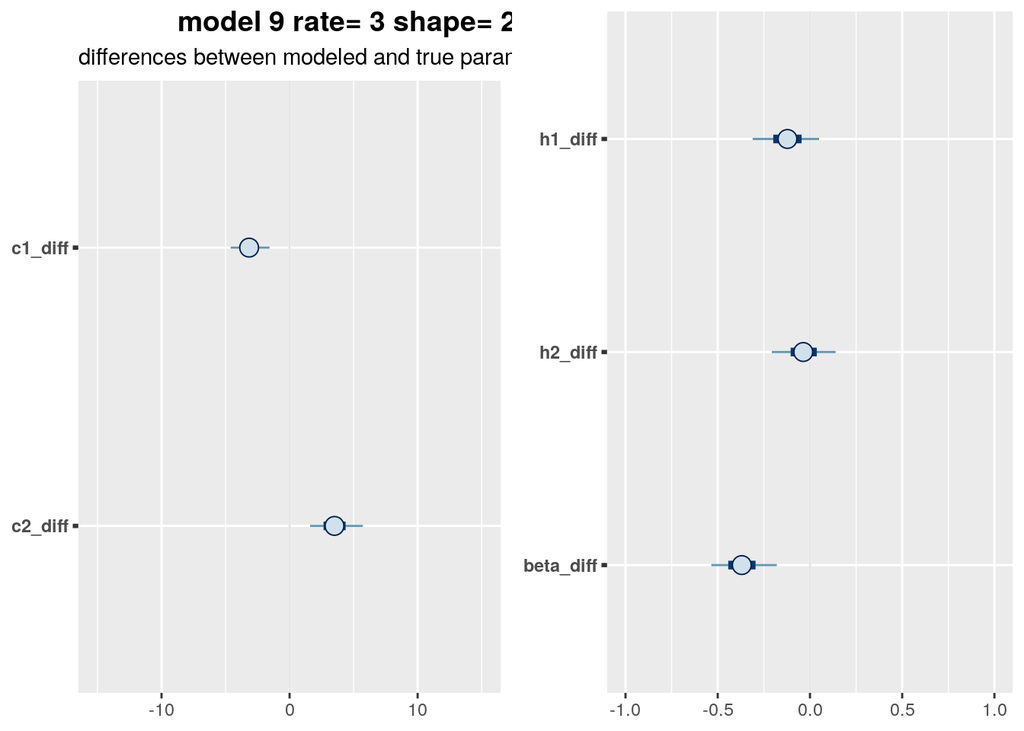

```
##
## $`10`
```

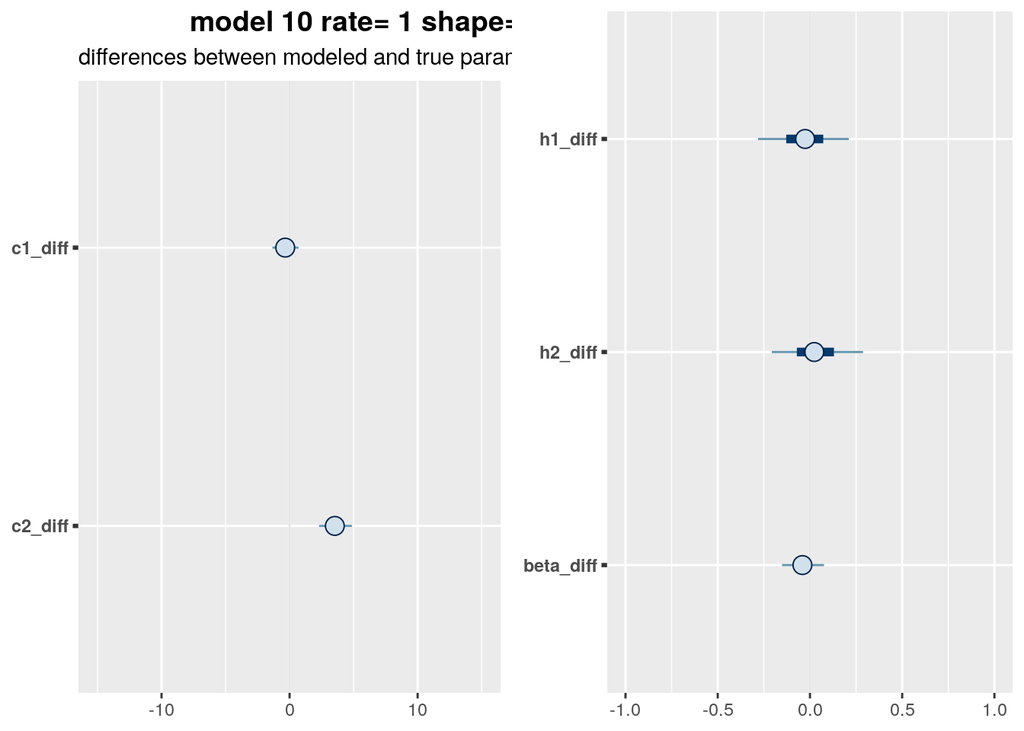

```
##
## $`11`
```

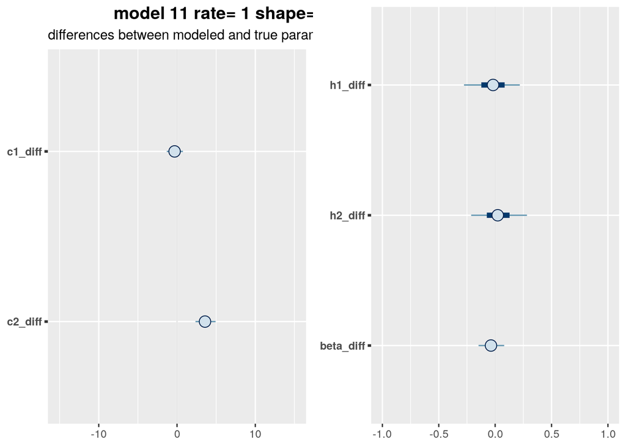

```
##
## $`12`
```

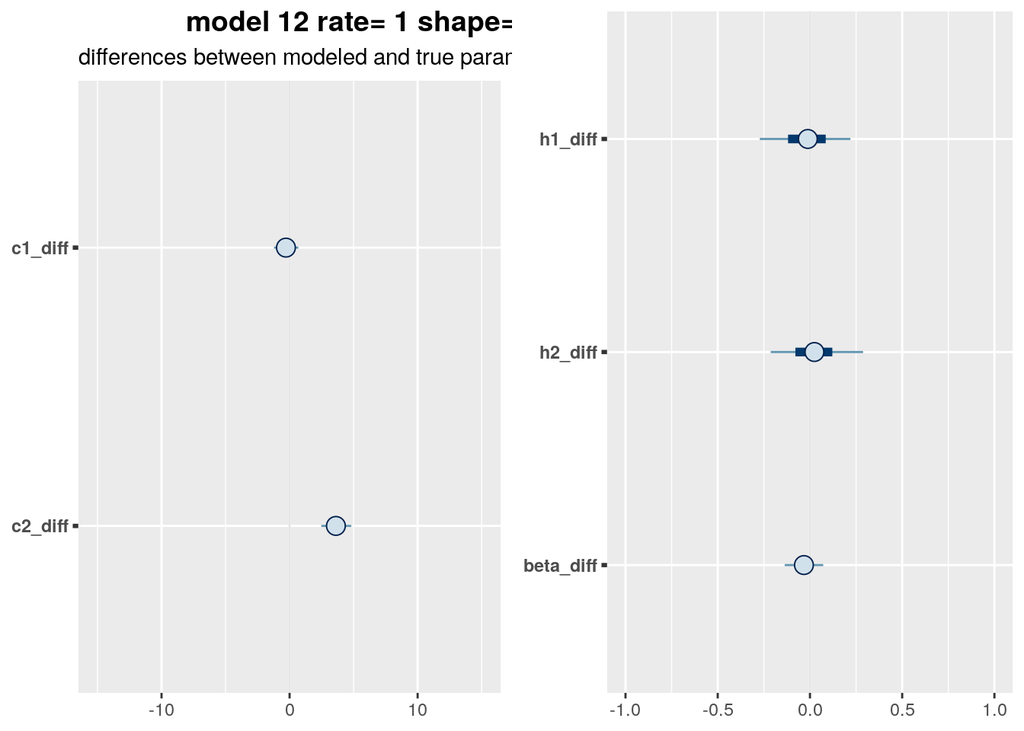

```
##
## $`13`
```

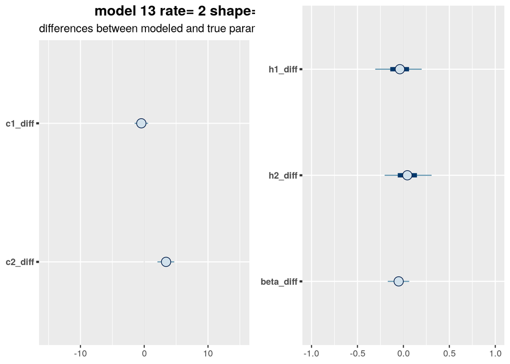

```
##
## $`14`
```

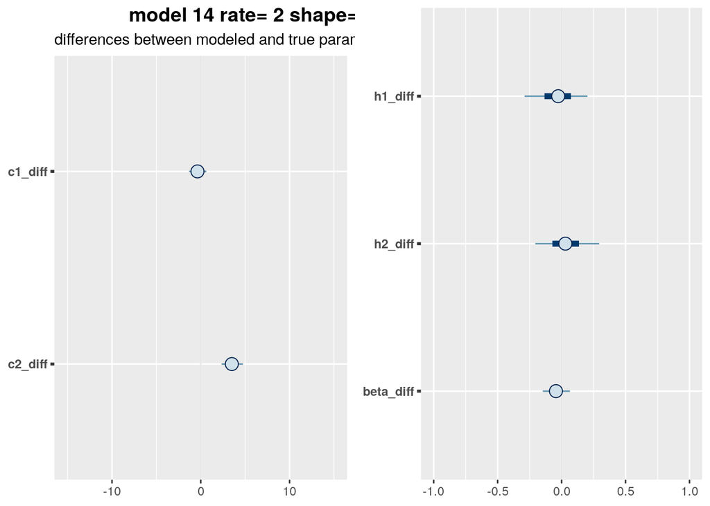

```
##
## $`15`
```

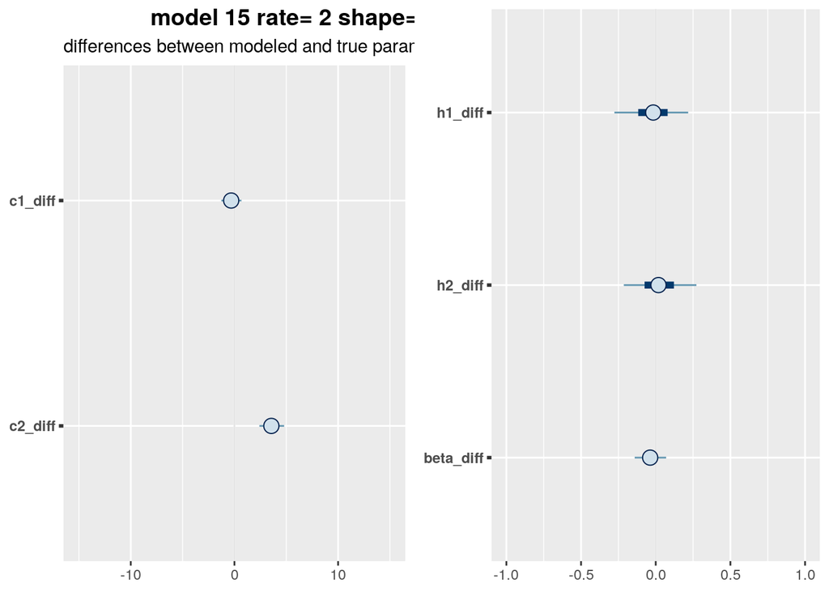

```
##
## $`16`
```

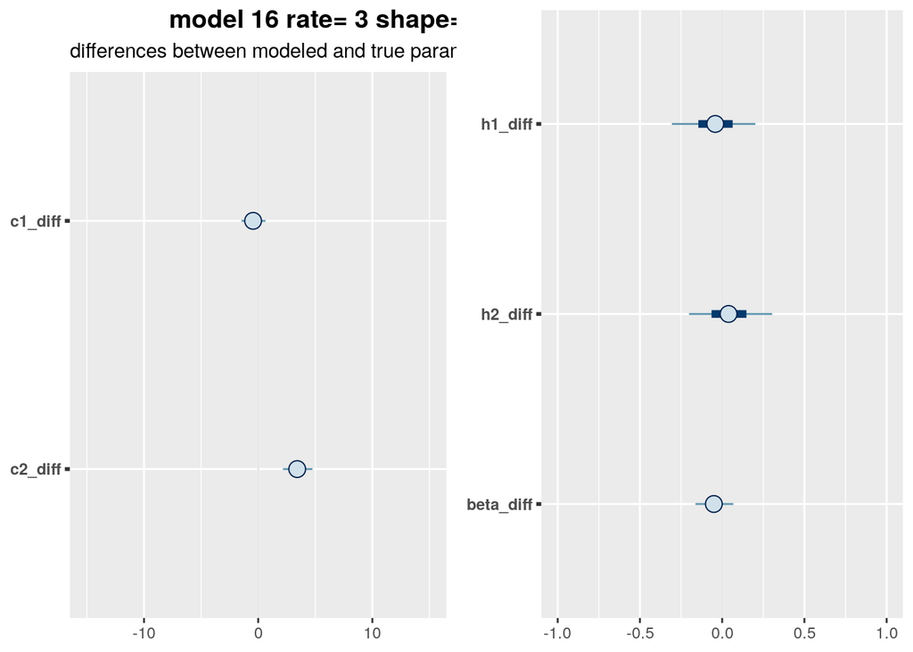

```
##
## $`17`
```

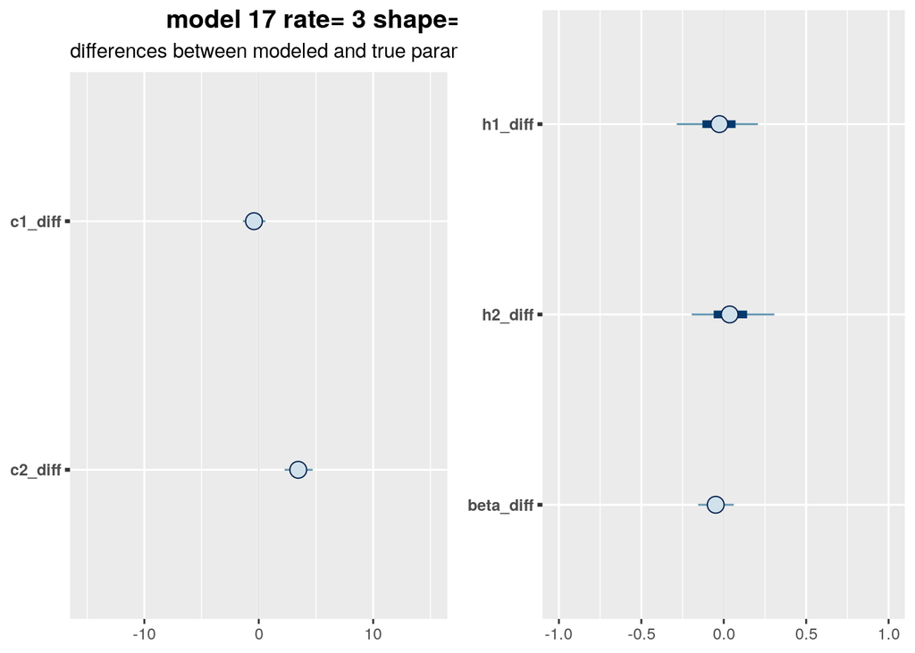

```
##
## $`18`
```

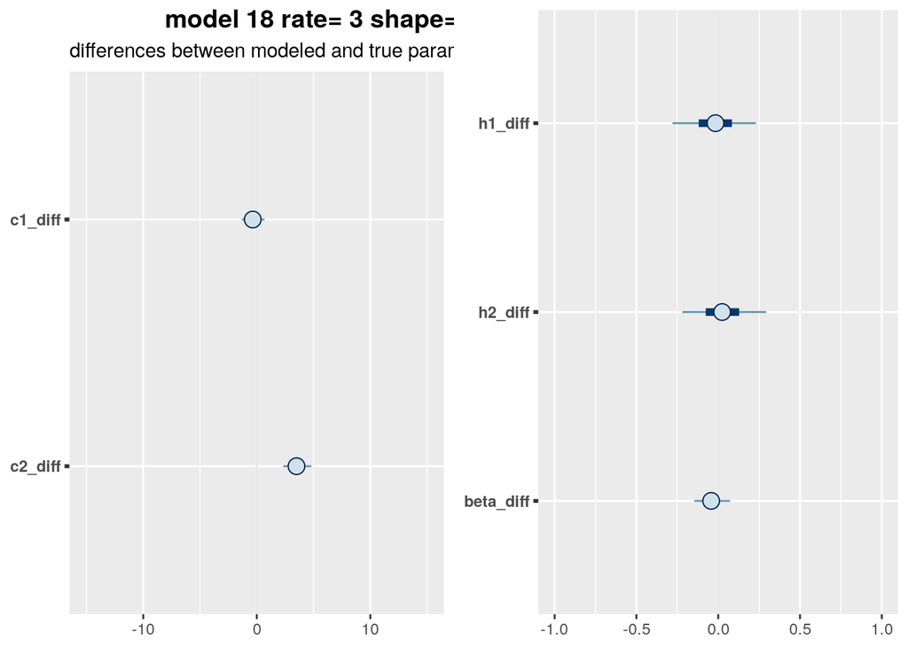

```
##
## $`19`
```

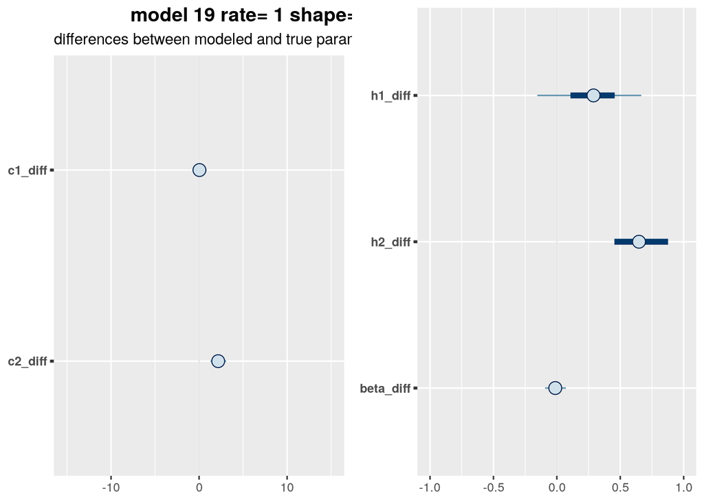

```
##
## $`20`
```

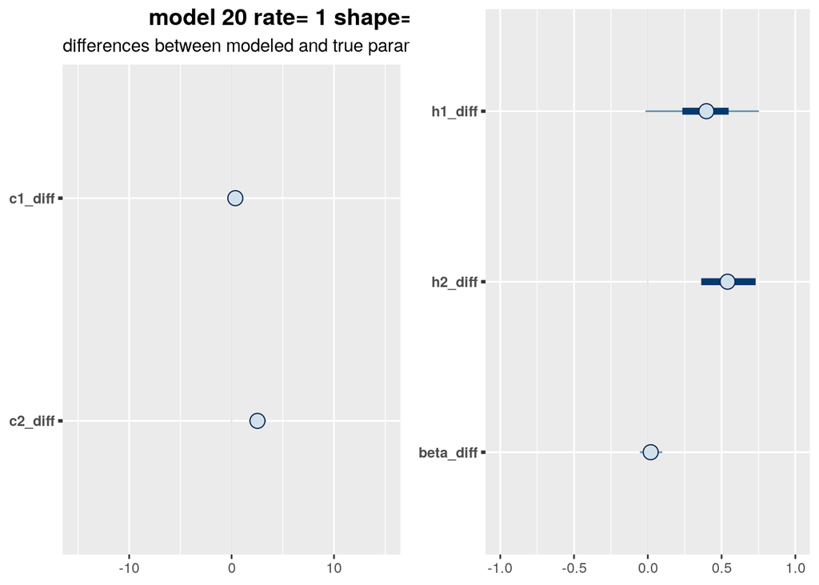

```
##
## $`21`
```

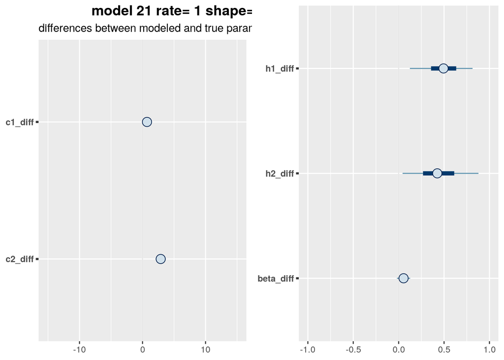

```
##
## $`22`
```

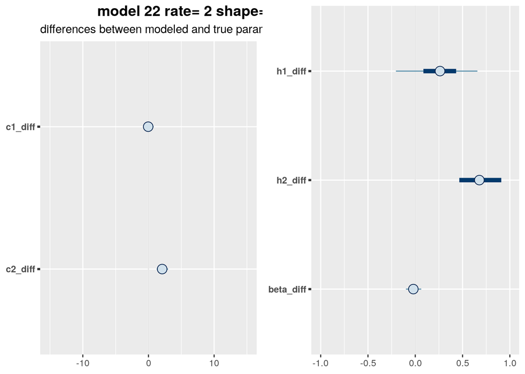

```
##
## $`23`
```

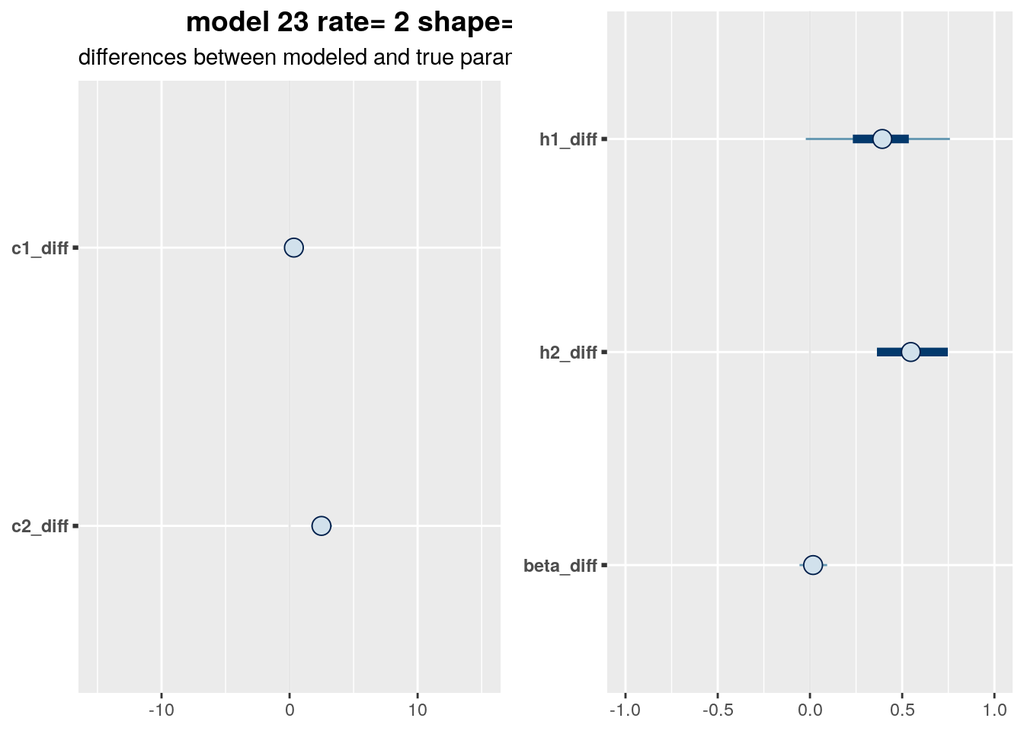

```
##
## $`24`
```

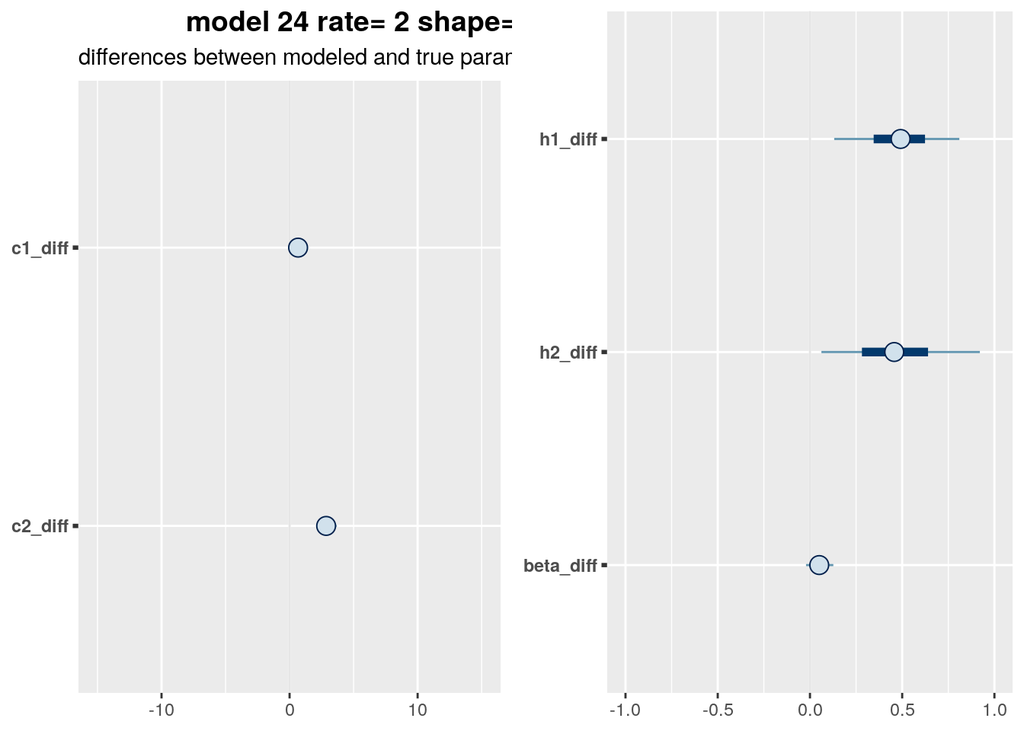

```
##
## $`25`
```

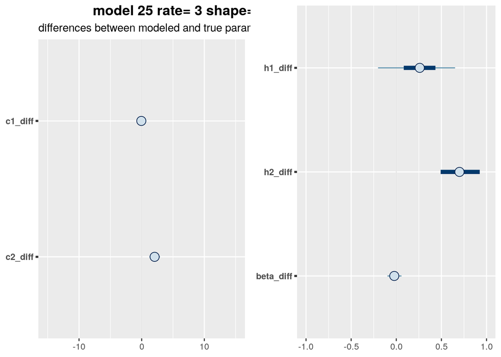

```
##
## $`26`
```

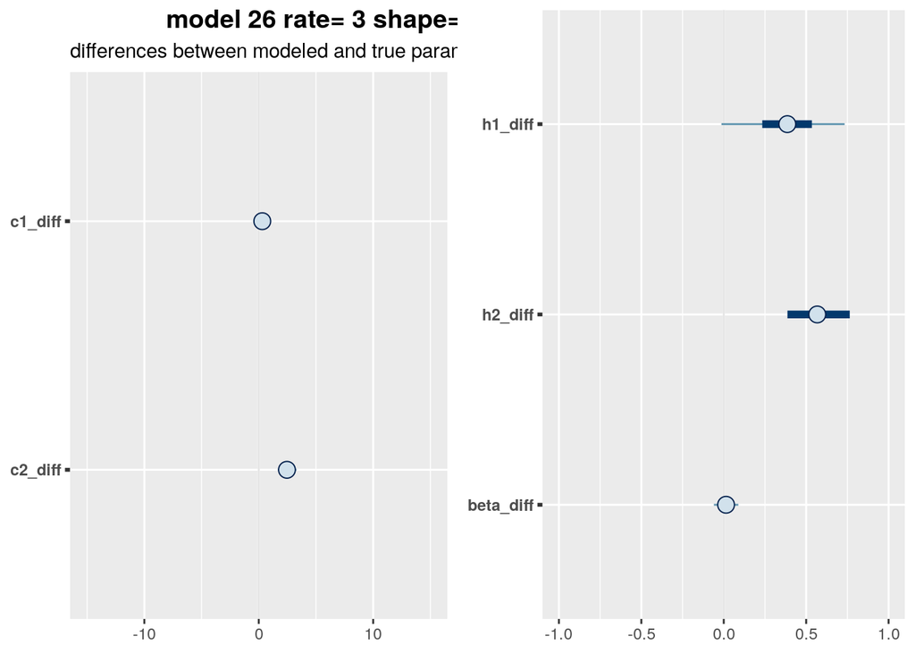

```
##
## $`27`
```

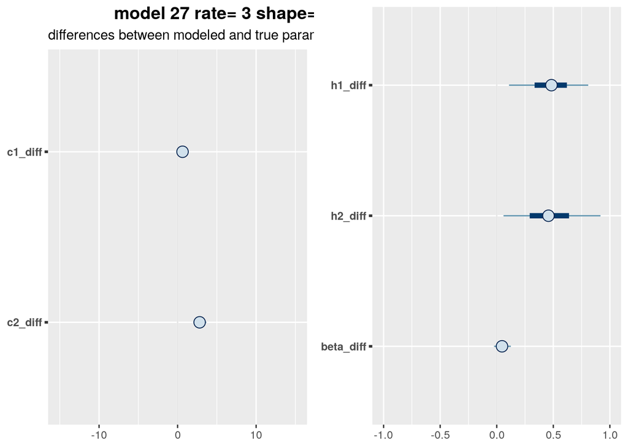

Proportion of params recaptured in 50% HPDI

| modelid | all_captured | gammaid | shape | cut_rate | beta_rate | transition | beta | c.1 | c.2 | h1 | h2 |
| --- | --- | --- | --- | --- | --- | --- | --- | --- | --- | --- | --- |
| 19 | 0.6 | fat | 2.5 | 0.25 | 1 | slow | 0.5 | 4 | 6 | 8 | 12 |
| 22 | 0.6 | fat | 2.5 | 0.25 | 2 | slow | 0.5 | 4 | 6 | 8 | 12 |
| 25 | 0.6 | fat | 2.5 | 0.25 | 3 | slow | 0.5 | 4 | 6 | 8 | 12 |
| 26 | 0.4 | normal | 10.0 | 1.00 | 3 | slow | 0.5 | 4 | 6 | 8 | 12 |
| 20 | 0.2 | normal | 10.0 | 1.00 | 1 | slow | 0.5 | 4 | 6 | 8 | 12 |
| 23 | 0.2 | normal | 10.0 | 1.00 | 2 | slow | 0.5 | 4 | 6 | 8 | 12 |
| 21 | 0.0 | skinny | 20.0 | 2.00 | 1 | slow | 0.5 | 4 | 6 | 8 | 12 |
| 24 | 0.0 | skinny | 20.0 | 2.00 | 2 | slow | 0.5 | 4 | 6 | 8 | 12 |
| 27 | 0.0 | skinny | 20.0 | 2.00 | 3 | slow | 0.5 | 4 | 6 | 8 | 12 |
| 10 | 1.0 | fat | 2.5 | 0.25 | 1 | medium | 1.0 | 8 | 12 | 8 | 12 |
| 11 | 1.0 | normal | 10.0 | 1.00 | 1 | medium | 1.0 | 8 | 12 | 8 | 12 |
| 12 | 1.0 | skinny | 20.0 | 2.00 | 1 | medium | 1.0 | 8 | 12 | 8 | 12 |
| 15 | 1.0 | skinny | 20.0 | 2.00 | 2 | medium | 1.0 | 8 | 12 | 8 | 12 |
| 14 | 0.8 | normal | 10.0 | 1.00 | 2 | medium | 1.0 | 8 | 12 | 8 | 12 |
| 13 | 0.6 | fat | 2.5 | 0.25 | 2 | medium | 1.0 | 8 | 12 | 8 | 12 |
| 16 | 0.6 | fat | 2.5 | 0.25 | 3 | medium | 1.0 | 8 | 12 | 8 | 12 |
| 18 | 0.6 | skinny | 20.0 | 2.00 | 3 | medium | 1.0 | 8 | 12 | 8 | 12 |
| 17 | 0.4 | normal | 10.0 | 1.00 | 3 | medium | 1.0 | 8 | 12 | 8 | 12 |
| 1 | 0.2 | fat | 2.5 | 0.25 | 1 | fast | 2.0 | 16 | 24 | 8 | 12 |
| 2 | 0.2 | normal | 10.0 | 1.00 | 1 | fast | 2.0 | 16 | 24 | 8 | 12 |
| 3 | 0.2 | skinny | 20.0 | 2.00 | 1 | fast | 2.0 | 16 | 24 | 8 | 12 |
| 4 | 0.2 | fat | 2.5 | 0.25 | 2 | fast | 2.0 | 16 | 24 | 8 | 12 |
| 5 | 0.2 | normal | 10.0 | 1.00 | 2 | fast | 2.0 | 16 | 24 | 8 | 12 |
| 6 | 0.2 | skinny | 20.0 | 2.00 | 2 | fast | 2.0 | 16 | 24 | 8 | 12 |
| 7 | 0.2 | fat | 2.5 | 0.25 | 3 | fast | 2.0 | 16 | 24 | 8 | 12 |
| 8 | 0.2 | normal | 10.0 | 1.00 | 3 | fast | 2.0 | 16 | 24 | 8 | 12 |
| 9 | 0.2 | skinny | 20.0 | 2.00 | 3 | fast | 2.0 | 16 | 24 | 8 | 12 |

Proportion of params recaptured in 90% HPDI

| modelid | all_captured | gammaid | shape | cut_rate | beta_rate | transition | beta | c.1 | c.2 | h1 | h2 |
| --- | --- | --- | --- | --- | --- | --- | --- | --- | --- | --- | --- |
| 19 | 0.8 | fat | 2.5 | 0.25 | 1 | slow | 0.5 | 4 | 6 | 8 | 12 |
| 20 | 0.8 | normal | 10.0 | 1.00 | 1 | slow | 0.5 | 4 | 6 | 8 | 12 |
| 22 | 0.8 | fat | 2.5 | 0.25 | 2 | slow | 0.5 | 4 | 6 | 8 | 12 |
| 25 | 0.8 | fat | 2.5 | 0.25 | 3 | slow | 0.5 | 4 | 6 | 8 | 12 |
| 23 | 0.6 | normal | 10.0 | 1.00 | 2 | slow | 0.5 | 4 | 6 | 8 | 12 |
| 26 | 0.6 | normal | 10.0 | 1.00 | 3 | slow | 0.5 | 4 | 6 | 8 | 12 |
| 21 | 0.4 | skinny | 20.0 | 2.00 | 1 | slow | 0.5 | 4 | 6 | 8 | 12 |
| 24 | 0.4 | skinny | 20.0 | 2.00 | 2 | slow | 0.5 | 4 | 6 | 8 | 12 |
| 27 | 0.4 | skinny | 20.0 | 2.00 | 3 | slow | 0.5 | 4 | 6 | 8 | 12 |
| 10 | 1.0 | fat | 2.5 | 0.25 | 1 | medium | 1.0 | 8 | 12 | 8 | 12 |
| 11 | 1.0 | normal | 10.0 | 1.00 | 1 | medium | 1.0 | 8 | 12 | 8 | 12 |
| 12 | 1.0 | skinny | 20.0 | 2.00 | 1 | medium | 1.0 | 8 | 12 | 8 | 12 |
| 13 | 1.0 | fat | 2.5 | 0.25 | 2 | medium | 1.0 | 8 | 12 | 8 | 12 |
| 14 | 1.0 | normal | 10.0 | 1.00 | 2 | medium | 1.0 | 8 | 12 | 8 | 12 |
| 15 | 1.0 | skinny | 20.0 | 2.00 | 2 | medium | 1.0 | 8 | 12 | 8 | 12 |
| 16 | 1.0 | fat | 2.5 | 0.25 | 3 | medium | 1.0 | 8 | 12 | 8 | 12 |
| 17 | 1.0 | normal | 10.0 | 1.00 | 3 | medium | 1.0 | 8 | 12 | 8 | 12 |
| 18 | 1.0 | skinny | 20.0 | 2.00 | 3 | medium | 1.0 | 8 | 12 | 8 | 12 |
| 1 | 1.0 | fat | 2.5 | 0.25 | 1 | fast | 2.0 | 16 | 24 | 8 | 12 |
| 4 | 1.0 | fat | 2.5 | 0.25 | 2 | fast | 2.0 | 16 | 24 | 8 | 12 |
| 7 | 1.0 | fat | 2.5 | 0.25 | 3 | fast | 2.0 | 16 | 24 | 8 | 12 |
| 2 | 0.4 | normal | 10.0 | 1.00 | 1 | fast | 2.0 | 16 | 24 | 8 | 12 |
| 3 | 0.4 | skinny | 20.0 | 2.00 | 1 | fast | 2.0 | 16 | 24 | 8 | 12 |
| 5 | 0.4 | normal | 10.0 | 1.00 | 2 | fast | 2.0 | 16 | 24 | 8 | 12 |
| 6 | 0.4 | skinny | 20.0 | 2.00 | 2 | fast | 2.0 | 16 | 24 | 8 | 12 |
| 8 | 0.4 | normal | 10.0 | 1.00 | 3 | fast | 2.0 | 16 | 24 | 8 | 12 |
| 9 | 0.4 | skinny | 20.0 | 2.00 | 3 | fast | 2.0 | 16 | 24 | 8 | 12 |

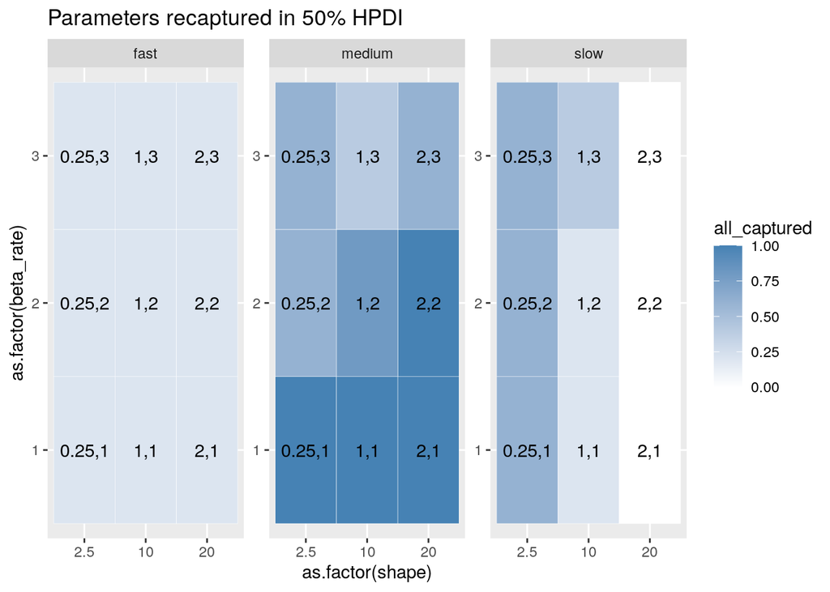

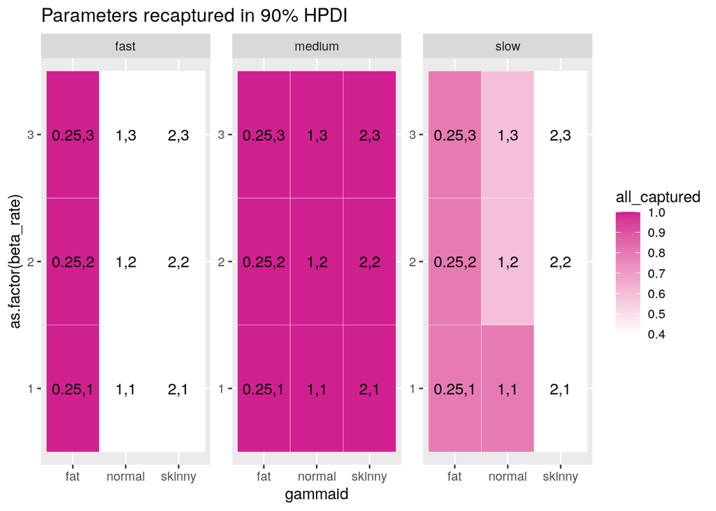